# Tutorial for de novo ‘Differentially methylated region-search’ using DiMmer

Manas Sehgal

Feburary 13, 2025

This vignette comprehensive instructions to obtaining *de novo* differentially-methylated regions (DMRs) between the user-defined sample groups using `DiMmer`<sup>(1)</sup>, following a successful CpG-level differential methylation analysis with `RnBeads` for `Infinium HumanMethylation450 BeadChip` and `Infinium MethylationEPIC v1.0` datasets.

## Introduction

Differentially-methylated regions (DMRs) are contiguous regions of the genome exhibiting context-specific differential methylation. `DiMmer` facilitates *de novo* identification of such regions. Prior to employing `DiMmer`, it is essential to conduct a CpG-level differential methylation analysis using `RnBeads`.

## Prerequistes

**1. Java installation**: Ensure that a suitable version of Java and Java Development Kit (JDK) 11 or above is installed on your system.

**2. Running RnBeads**: The *de novo* differentially-methylated region search requires CpG site-level differential methylation results from `RnBeads`. Detailed instructions on executing `RnBeads` for your methylome data can be accessed [here.](https://rnbeads.org/tutorial.html)

## Download and run DiMmer

After successfully running the differential methylation analyses for all desired sample group comparisons using `RnBeads`,

1. Create a sub-directory within the `RnBeads` results directory titled ‘dimmer’.
2. Subsequently, download the `dimmer.jar` file, `dimmer_console.config` file for `DiMmer v2.3` from [here](https://github.com/daisybio/Dimmer/releases/tag/2.3) and this R script, and move them into the ‘dimmer’ directory.
3. Execute the script in R/Rstudio with the following command:

`source('./dmrsearch.R')`

**NOTE:** DMR search parameters used by DiMmer are defined in `dmrsearch.R`. If required, these parameters can be altered within the ‘config’ variable in this script.

## Example outcome

This workflow was utilized to identify *de novo* DMRs between induced pluripotent stem cell (iPSC) and non-iPSC samples from a `Infinium HumanMethylation450 BeadChip` dataset with Gene expression omnibus (GEO) accession number—GSE76372<sup>(2)</sup>.

Based on differential methylation of individual CpGs between sample groups, `DiMmer` identifies *de novo* DMRs and generates `dimmer.csv` containing scores and p-values for each DMR (Figure 1)<sup>1</sup>.

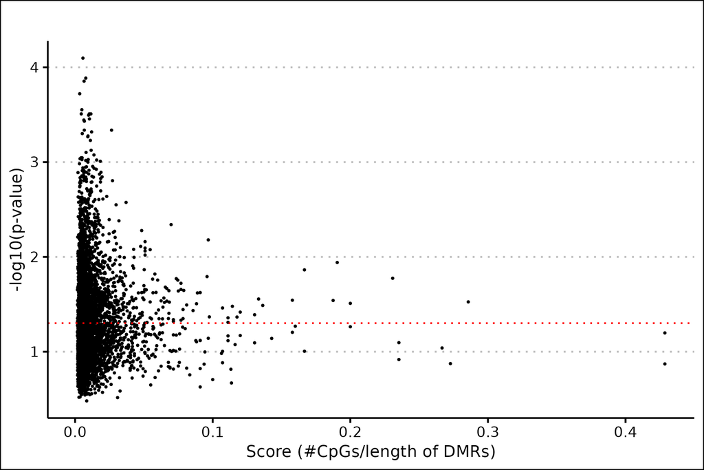

**Figure 1**: Scatterplot depicting relationship between the output scores (x-axis) and -log<sub>10</sub>(p-values) (y-axis) for the 5811 *de novo* DMRs identified by DiMmer between iPSC vs. non-iPSC samples from a 450K methylation array dataset<sup>(2)</sup>. *p-value* of 0.05 is indicated by the horizontal red line.

## References

1. Frisch T, Gøttcke J, Röttger R, Tan Q, Baumbach J. DiMmer: Discovery of Differentially Methylated Regions in Epigenome-Wide Association Study (EWAS) Data. Methods Mol Biol. 2018;1807:51-62. doi: 10.1007/978-1-4939-8561-6_5. PMID: 30030803.
2. Kitayama S, Zhang R, Liu TY, Ueda N, Iriguchi S, Yasui Y, Kawai Y, Tatsumi M, Hirai N, Mizoro Y, Iwama T, Watanabe A, Nakanishi M, Kuzushima K, Uemura Y, Kaneko S. Cellular Adjuvant Properties, Direct Cytotoxicity of Re-differentiated Vα24 Invariant NKT-like Cells from Human Induced Pluripotent Stem Cells. Stem Cell Reports. 2016 Feb 9;6(2):213-27. doi: 10.1016/j.stemcr.2016.01.005. PMID: 26862702; PMCID: PMC4750166.